# Hypothetical Outcome Plots

Will Bonnell

2020-02-05

# The Uncertainty of Uncertainty

Conveying uncertainty in data visualisations has become a growing topic in data visualisation circles in the past few years. When considering how to visualise data, one must consider who their audience is and how that audience might interpret a visualisation. In the same way writers adopt different styles of writing to convey information to different audiences, dataviz practioners might choose color, layout, or typography to suit different audiences (e.g. making a color palette color blind friendly or right-aligning a visualization designed for [RTL-writing](https://en.wikipedia.org/wiki/Right-to-left) communities. The options a dataviz practitioner has though are not limited only to the aesthetic design choices. The practitioner’s decision to use a certain type of visualisation itself is contingent on the audience’s ability to understand it.

This is especially true when visualising the uncertainty we as researchers know exist. While a statistician or analyst in your company or academic department might understand the error bars on a bar chart you send them, the average person might not. This has prompted discussion about ways we visualise uncertainty.

# How We Historically Visualise Uncertainty

Conventionally, one might express the uncertainty of a mean value by creating a confidence interval of the difference of a mean and standard deviation. We could express that deviation in an error bar, like such:

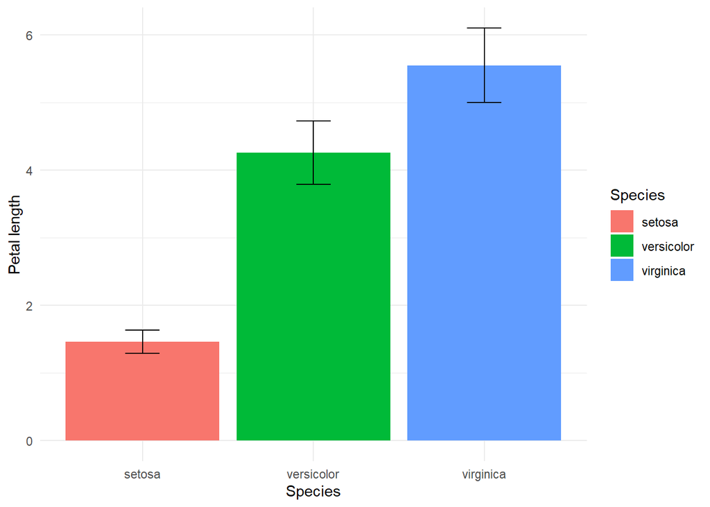

Error bars on Iris data

```r
library(ggplot2)
library(dplyr)
iris_sum <- iris %>%
  group_by(Species) %>%
  summarise(mean = mean(Petal.Length),
            sd = sd(Petal.Length))

g <- ggplot(iris_sum, aes(Species, mean, fill = Species)) +
  geom_col() +
  geom_errorbar(aes(ymin = mean - sd, ymax = mean + sd), width = 0.2) +
  labs(y = "Petal length") +
  theme_minimal()
g
```

While this creates clarity that there is *some* uncertainty, it might also convey that probabilistically the likelihood of this value can only fall in this bar and is equally likely to be any point within these bars. One might be able to better express this uncertainty by creating a violin plot of distributions of simualated or real values.

[figure not shown]

```r
mb <- microbenchmark(x, y, n = 50)
ggplot2::autoplot(mb) +
  theme_minimal()
```

# Alternatives

In the era of modern data visualisation we have more tools at hand than conventional depictions of uncertainty in error bars or violin plots. A recent development in conveying of uncertainty is the innovation of hypothetical outcome plots (HOPs), which are animated plots or graphs that show potential values in a distribution (e.g. Bayesian MCMC sampled data, bootstrapped data, or a real distribution like our plot above).

HOPs have the advantage of requiring relatively little background knowledge to interpret as they only require a viewer to understand a single real value at different times. In [testing on subjects](http://users.eecs.northwestern.edu/~jhullman/HOPS_PLOS_preprint.pdf), these outperformed error bars consistently and outperformed violin plots in certain one-variable trials. Subjects were better able to estimate cumulative densities when variance was low when using HOPs than violin plots or error bars.

# Creating HOPs

Creating HOPs in R is pretty simple with {gganimate}. For a one-variable trials like Hullman, Resnick, and Adar create, we can use `geom_errorbar()` as we did above, but we will add a `transition_states()` call to animate it.

Let’s look at our benchmark data:

```r
mb <- read.csv("mbtest.csv")
head(mb)
```

```
##   X                                          expr        time
## 1 1        df.list <- lapply(file.list, read_csv) 17483605629
## 2 2 df.list <- future_lapply(file.list, read_csv) 11911994096
## 3 3 df.list <- future_lapply(file.list, read_csv)  9941619312
## 4 4        df.list <- lapply(file.list, read_csv) 17726280555
## 5 5 df.list <- future_lapply(file.list, read_csv) 12778679896
## 6 6        df.list <- lapply(file.list, read_csv) 20202289703
```

We simply need to assign frame to each of these expressions and then set the `transition_states()` function to reference frame. In this case we want `frame` to equal `1` for one of each function, and then `frame` to equal `2` for one of each function, and so on. We can just use the rep function to assiign this column. Frame should be unique for whatever you are animating. This is the output we will feed into our ggplot:

```r
mb1 <- mb %>%
  mutate(expr = as.character(expr)) %>%
  mutate(frame = rep(1:(100/2), each = 2))

head(mb1)
```

```
##   X                                          expr        time frame
## 1 1        df.list <- lapply(file.list, read_csv) 17483605629     1
## 2 2 df.list <- future_lapply(file.list, read_csv) 11911994096     1
## 3 3 df.list <- future_lapply(file.list, read_csv)  9941619312     2
## 4 4        df.list <- lapply(file.list, read_csv) 17726280555     2
## 5 5 df.list <- future_lapply(file.list, read_csv) 12778679896     3
## 6 6        df.list <- lapply(file.list, read_csv) 20202289703     3
```

Then we create our `ggplot()` with the data argument set to the data set and the aesthetics set to expr and time like we would set up a normal bar chart, but instead of using geom_bar() we will just use `geom_errorbar()` and then animate its movement. We set `transition_states()` to reference the `frame` column and then can set the `transition_length` parameter to equal 2 frames.

```r
library(gganimate)
library(av)
```

```r
test <- ggplot(mb1, aes(expr, time)) +
  geom_errorbar(aes(ymin = time, ymax = time)) +
  theme_minimal() +
  theme(axis.title.y = element_text(margin = margin(r = 20))) +
  transition_states(frame, transition_length = 2, state_length = 1) +
  enter_fade() +
  exit_shrink()

animate(test, renderer = av_renderer())
```

[video not shown]

We can then add a `shadow_mark()` element to keep the past and future frames of the animation so you can see all the potential values and set these to a light grey so they don’t interrupt the animation:

```r
ggplot(mb1, aes(expr, time)) +
  geom_errorbar(aes(ymin = time, ymax = time)) +
  theme_minimal() +
  theme(axis.title.y = element_text(margin = margin(r = 20))) +
  transition_states(frame, transition_length = 2, state_length = 1) +
  enter_fade() +
  exit_shrink() +
  ease_aes('sine-in-out') +
  shadow_mark(past = TRUE, future = TRUE, color = "#d3d3d3") +
  labs(x = "Function", y = "Time to run")
```

[output not shown]

Voila! We have our first one-variable hypothetical outcome plot representing the distribution of our code benchmarks above.

# More examples

For more information about how one can create synthetic/simulated data for the creation of HOPs, I recommend Claus Wilke’s `rstudio::conf` [2019 presentation](https://resources.rstudio.com/rstudio-conf-2019/visualizing-uncertainty-with-hypothetical-outcomes-plots) on the subject. His slides have examples of bootstrapping and sampling data for inclusion in HOPs.